# subhankar’s Progress

Jalaj

## Data-Set

Our dataset is a collection of 1313 CXR images containing COVID-19 positive and negative samples. There is a problem of class imbalance as we had 1000 negative samples compared to only 313 positive samples. The local binary patterns that we extracted from the CXR images have 58 dimensions. For class imbalance, we have implemented an oversampling technique that is provided by the R package ‘ROSE’, which basically means Random Over Sampling Examples. It’s a resampling function that generates synthetic balanced samples using holdout, bootstrap or cross-validation methods.

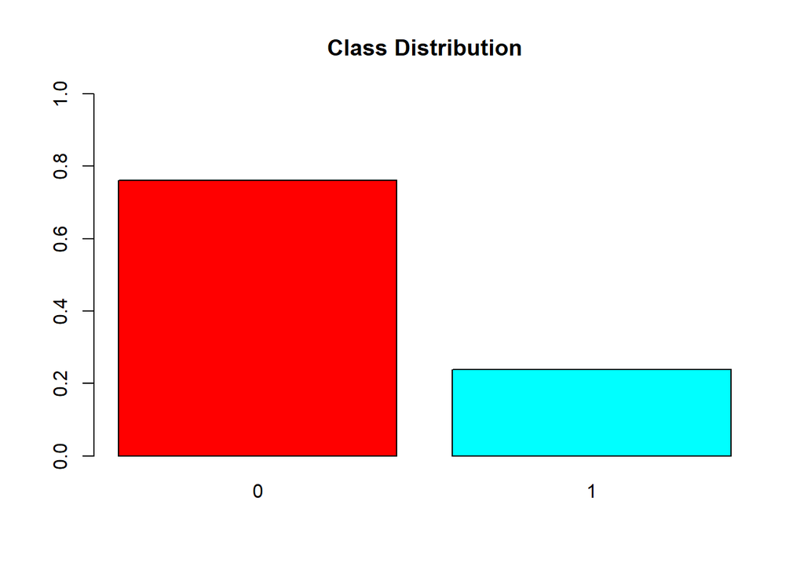

```r
#Visualizing distribution of each class
barplot(prop.table(table(covid_data$V59)),
        col = rainbow(2),
        ylim = c(0,1),
        main = "Class Distribution")
```

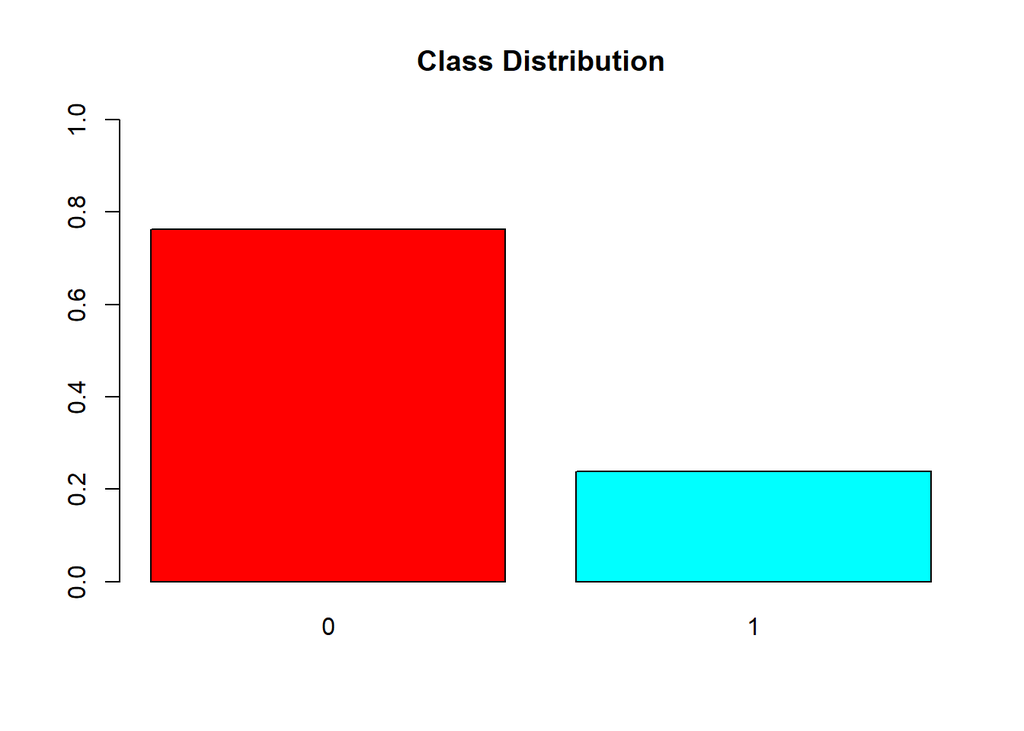

```r
barplot(prop.table(table(train$V59)),
        col = rainbow(2),
        ylim = c(0,1),
        main = "Class Distribution")
```

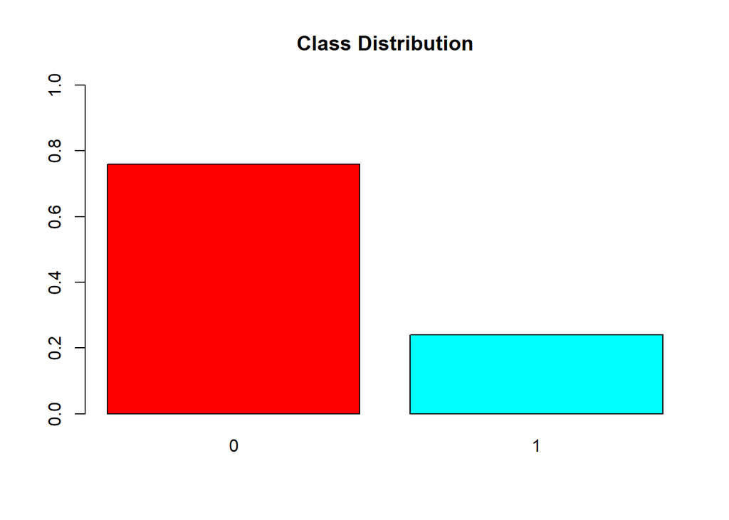

```r
barplot(prop.table(table(test$V59)),
        col = rainbow(2),
        ylim = c(0,1),
        main = "Class Distribution")
```

```r
#Training Models
library(randomForest)
```

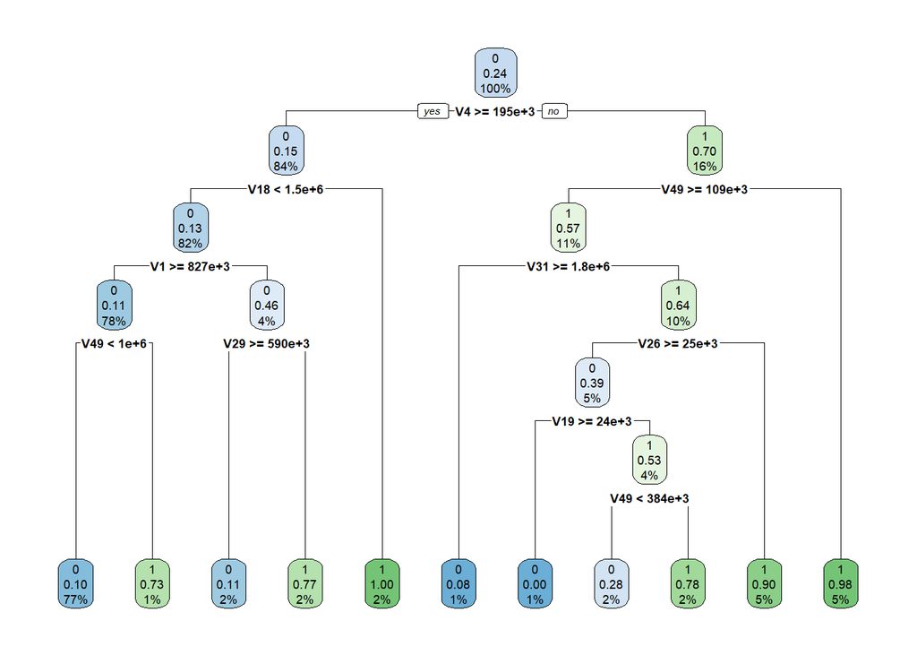

```r
library(rpart)
library(rpart.plot)
#Random Forest
rftrain <- randomForest(V59~.,data = train)
#Decision Tree
dttrain <- rpart(V59~.,data = train, method = "class")
dttrain_criteria <- rpart(V59~.,data = train, method = "class", minsplit = 20, minbucket = 10)
rpart.plot(dttrain)
rpart.plot(dttrain_criteria)
```

[output not shown]